# Weight of Fish

Christina Jones

Fall 2021

```r
fish <- read.csv("Fish.csv")
```

# 1 Introduction

Build the best regression model to predict the weight of Perch, Pike and Roach that uses two predictor variables. We are trying to find the best two variable to predict weight of each type of fish.

## 1.1 Build the best regression model you can that predicts the weight of Perch

## 1.2 Using only two predictor variables

# 2 Methods

Subset of fish that contains the species you want to analyze and then I will look at how well each combination of the predictor variables can predict the weight of a fish. The PERCH will be the first species of fish.

```r
Perch = filter(fish, Species=="Perch")
```

# 3 Results For Perch

## 3.1 Descriptive Results

### 3.1.1 Graphical Descriptive Results

```r
basicNN <- ggplot(Perch,aes(y=Weight,x=Length1))
```

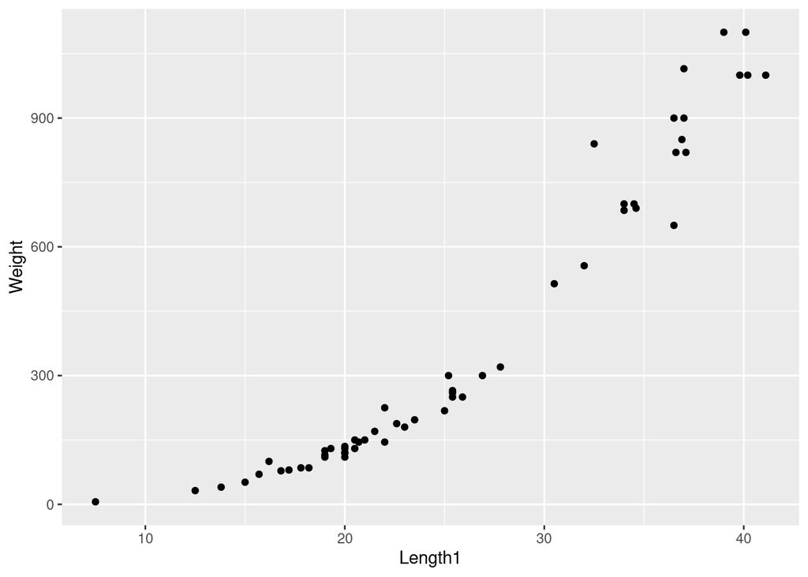

```r
basicNN + geom_point()
```

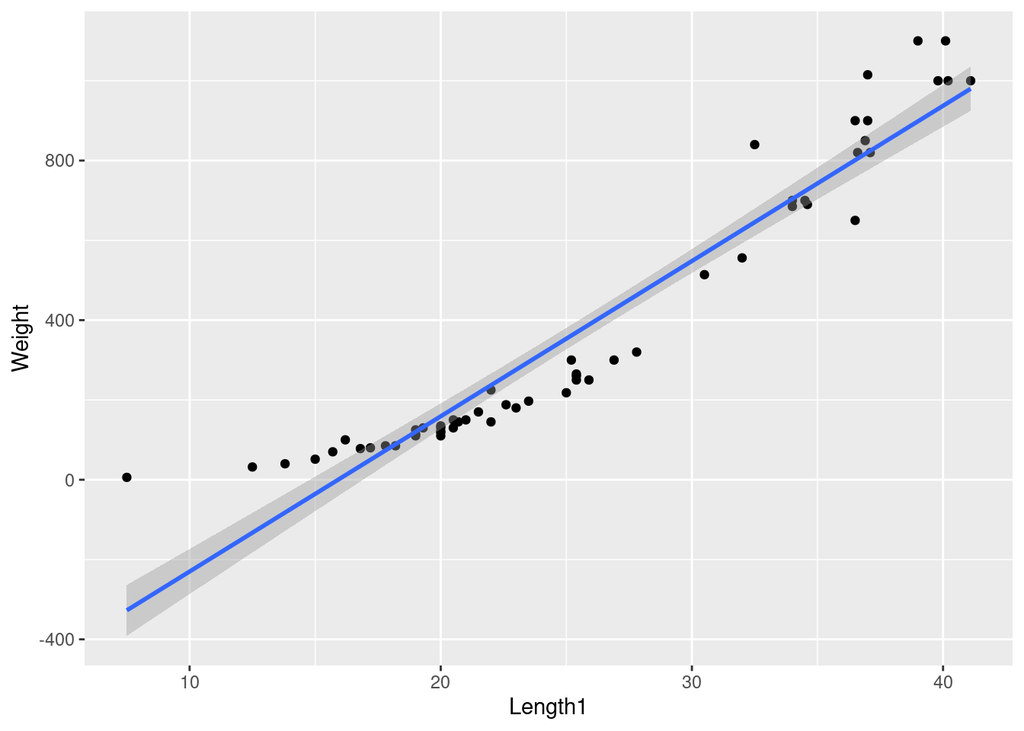

```r
basicNN + geom_point() + geom_smooth(method=lm)
```

On the Y axis Weight is represented and on the x axis Length1 is represented. As the Length1 increases so does the weight of the Perch fish.If this were a linear fit that would describe where the line would be. This is not a linear fit, the blue line would represents the regression between the two variables if this was a linear fit. The intercepts do not fall evenly on the blue line.

### 3.1.2 Numerical Descriptive Results

```r
library(leaps)
regsubsets.out <-
    regsubsets(Weight ~ .,
               data = select (Perch, -Species),
               nbest = 1,       # 1 best model for each number of predictors
               nvmax = NULL,    # NULL for no limit on number of variables
               force.in = NULL, force.out = NULL,
               method = "exhaustive")

summary.out <- summary(regsubsets.out)
as.data.frame(summary.out$outmat)
```

```
##          Length1 Length2 Length3 Height Width
## 1  ( 1 )                              *
## 2  ( 1 )                              *     *
## 3  ( 1 )                       *      *     *
## 4  ( 1 )               *       *      *     *
## 5  ( 1 )       *       *       *      *     *
```

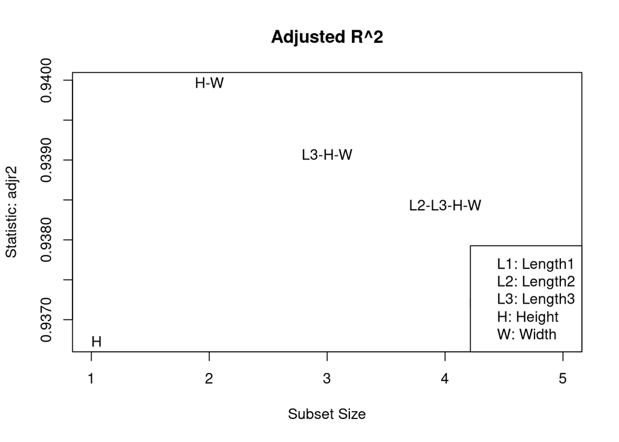

```r
library(car)
subsets(regsubsets.out,statistic="adjr2",legend="bottomright",main="Adjusted R^2")
```

This graph shows that the Y axis is the adjusted R squared while the X axis is the subsets. This model using all the variables, Perch fish Weight can better be predicted when using one variable use Height of the fish. When using two variables use Height and Width to predict Weight. When using three variables use Length3, Height and Width to predict Weight of Perch.

```r
which.max(summary.out$adjr2)
```

```
## [1] 2
```

```r
summary.out$which[2,]
```

```
## (Intercept)     Length1     Length2     Length3      Height       Width
##        TRUE       FALSE       FALSE       FALSE        TRUE        TRUE
```

This summary shows the best two variables to predict Weight of Perch are Height and Width come as TRUE.

```r
best.model <- lm(Weight~Height+Width,data=Perch)
summary(best.model)
```

```
##
## Call:
## lm(formula = Weight ~ Height + Width, data = Perch)
##
## Residuals:
##     Min      1Q  Median      3Q     Max
## -143.98  -52.99  -21.83   44.53  285.96
##
## Coefficients:
##             Estimate Std. Error t value Pr(>|t|)
## (Intercept)  -536.00      33.38 -16.058  < 2e-16 ***
## Height         74.77      21.70   3.446  0.00112 **
## Width          69.62      35.19   1.978  0.05309 .
## ---
## Signif. codes:  0 '***' 0.001 '**' 0.01 '*' 0.05 '.' 0.1 ' ' 1
##
## Residual standard error: 85.17 on 53 degrees of freedom
## Multiple R-squared:  0.9421, Adjusted R-squared:   0.94
## F-statistic: 431.6 on 2 and 53 DF,  p-value: < 2.2e-16
```

```r
fullup=lm(Weight~.,data=select(Perch,-Species))
```

Using the two best variables a linear model was used. The best prediction for weight = -536 + 74.77 * Height + 69.62 * width

The equation is the best fit for predict the weight of Perch using Height and Weight.

```r
anova(fullup,best.model)
```

```
## Analysis of Variance Table
##
## Model 1: Weight ~ Length1 + Length2 + Length3 + Height + Width
## Model 2: Weight ~ Height + Width
##   Res.Df    RSS Df Sum of Sq      F Pr(>F)
## 1     50 379369
## 2     53 384478 -3   -5109.1 0.2245  0.879
```

The P value of the comparison of Height and Width is 0.879 which is larger then 0.05.

## 3.2 Inferential Results

$H_0$ The model show no difference in the prediction of weight Perches.

$H_A$ The model helps with predicting the weight of Perches.

```r
anova(fullup,best.model)
```

```
## Analysis of Variance Table
##
## Model 1: Weight ~ Length1 + Length2 + Length3 + Height + Width
## Model 2: Weight ~ Height + Width
##   Res.Df    RSS Df Sum of Sq      F Pr(>F)
## 1     50 379369
## 2     53 384478 -3   -5109.1 0.2245  0.879
```

# 4 Discussion and Conclusion

Using all the variables to come up the best way to predict the weight of Perches. It is concluded the Height and Width is the best predictor for Perches Weight when using two varibles.

```r
Pike =filter(fish, Species=="Pike")
```

# 5 Results For Pike

## 5.1 Descriptive Results

### 5.1.1 Graphical Descriptive Results

```r
basicNN <- ggplot(Pike,aes(y=Weight,x=Length1))
```

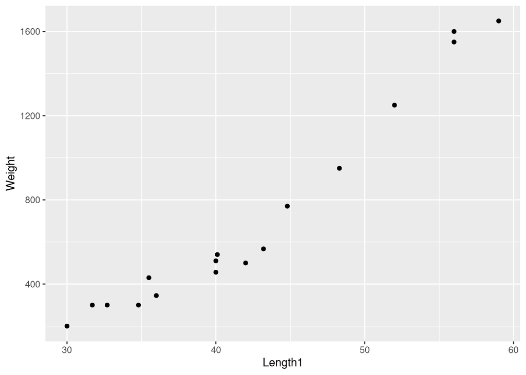

```r
basicNN + geom_point()
```

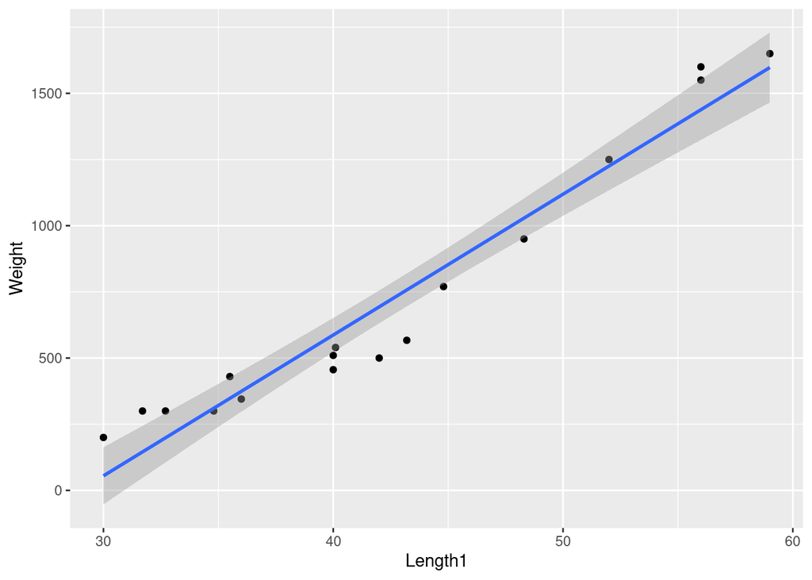

```r
basicNN + geom_point()+geom_smooth(method=lm)
```

On the Y axis Weight is represented and on the x axis length1 is represented. As the length1 increases so does the weight of the Pike fish. This model is a linear fit as the blue line and the intercepts go along each other more so then the regression line that was represented for Perch.

### 5.1.2 Numerical Descriptive Results

```r
library(leaps)
regsubsets.out <-
    regsubsets(Weight ~ .,
               data = select (Pike, -Species),
               nbest = 1,       # 1 best model for each number of predictors
               nvmax = NULL,    # NULL for no limit on number of variables
               force.in = NULL, force.out = NULL,
               method = "exhaustive")

summary.out <- summary(regsubsets.out)
as.data.frame(summary.out$outmat)
```

```
##          Length1 Length2 Length3 Height Width
## 1  ( 1 )                       *
## 2  ( 1 )       *               *
## 3  ( 1 )       *               *            *
## 4  ( 1 )       *               *      *     *
## 5  ( 1 )       *       *       *      *     *
```

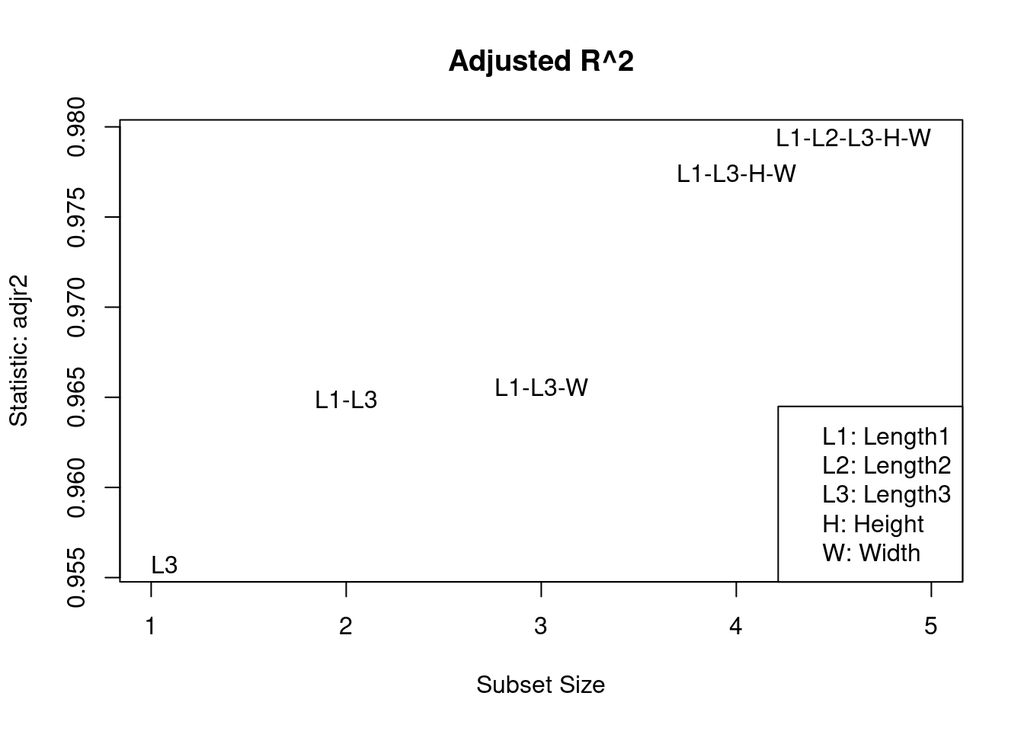

```r
library(car)
subsets(regsubsets.out,statistic="adjr2",legend="bottomright",main="Adjusted R^2")
```

This graph shows that the Y axis is the adjusted R squared while the X axis is the subsets. This model using all the variables, Pike fish Weight can better be predicted when using one variable use Length3 of the fish. When using two variables use Length3 and Length1 to predict Weight. When using three variables use Length3, Length1 and Width to predict Weight of Pike.

```r
which.max(summary.out$adjr2)
```

```
## [1] 5
```

```r
best.model <- lm(Weight~Length3+Length1,data=Pike)
summary(best.model)
```

```
##
## Call:
## lm(formula = Weight ~ Length3 + Length1, data = Pike)
##
## Residuals:
##     Min      1Q  Median      3Q     Max
## -167.67  -53.90  -15.81   32.29  151.18
##
## Coefficients:
##             Estimate Std. Error t value Pr(>|t|)
## (Intercept) -1675.79     118.25 -14.171 1.08e-09 ***
## Length3       141.25      42.24   3.344  0.00482 **
## Length1      -105.64      47.56  -2.221  0.04336 *
## ---
## Signif. codes:  0 '***' 0.001 '**' 0.01 '*' 0.05 '.' 0.1 ' ' 1
##
## Residual standard error: 92.56 on 14 degrees of freedom
## Multiple R-squared:  0.9693, Adjusted R-squared:  0.9649
## F-statistic:   221 on 2 and 14 DF,  p-value: 2.572e-11
```

```r
fullup=lm(Weight~.,data=select(Pike,-Species))
```

Using the two best variables a linear model was used. The best prediction for weight = -1675.79 + 141.25 * Length3 + -105.64 * Length1

Using this model shows all the variables, Pike fish weight can better be predicted when using Length3 and Length1 of the fish.

## 5.2 Inferential Results

$H_0$ The models show no difference in the prediction of weight of Pikes.

$H_A$ The models help with predicting the weight of Pikes.

```r
anova(fullup,best.model)
```

```
## Analysis of Variance Table
##
## Model 1: Weight ~ Length1 + Length2 + Length3 + Height + Width
## Model 2: Weight ~ Length3 + Length1
##   Res.Df    RSS Df Sum of Sq      F  Pr(>F)
## 1     11  55225
## 2     14 119949 -3    -64724 4.2973 0.03091 *
## ---
## Signif. codes:  0 '***' 0.001 '**' 0.01 '*' 0.05 '.' 0.1 ' ' 1
```

# 6 Discussion and Conclusion

Using all the variables to come up the best way to predict the weight of Pikes. It is concluded the Length3 and Length1 is the best predictor for the Weight of Pike.

```r
Roach =filter(fish, Species=="Roach")
```

# 7 Results For Roach

## 7.1 Descriptive Results

### 7.1.1 Graphical Descriptive Results

```r
basicNN <- ggplot(Roach,aes(y=Weight,x=Length1))
```

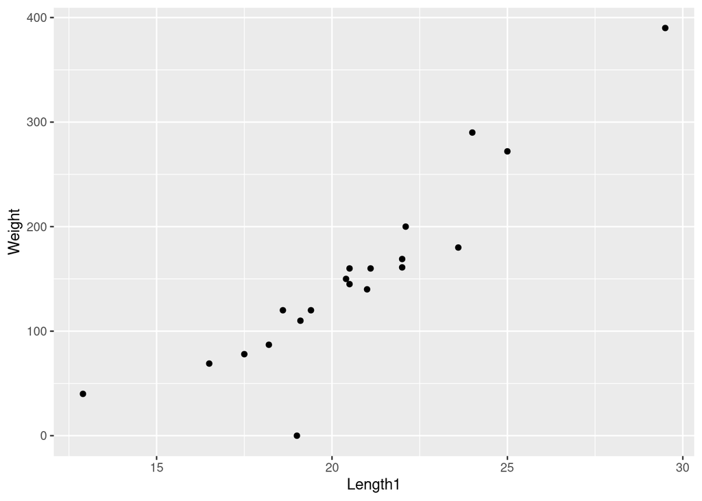

```r
basicNN + geom_point()
```

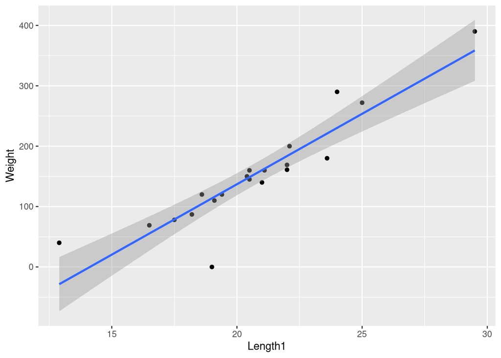

```r
basicNN + geom_point()+geom_smooth(method=lm)
```

### 7.1.2 Numerical Descriptive Results

```r
library(leaps)
regsubsets.out <-
    regsubsets(Weight ~ .,
               data = select (Roach, -Species),
               nbest = 1,       # 1 best model for each number of predictors
               nvmax = NULL,    # NULL for no limit on number of variables
               force.in = NULL, force.out = NULL,
               method = "exhaustive")

summary.out <- summary(regsubsets.out)
as.data.frame(summary.out$outmat)
```

```
##          Length1 Length2 Length3 Height Width
## 1  ( 1 )                                    *
## 2  ( 1 )                       *            *
## 3  ( 1 )       *               *            *
## 4  ( 1 )       *               *      *     *
## 5  ( 1 )       *       *       *      *     *
```

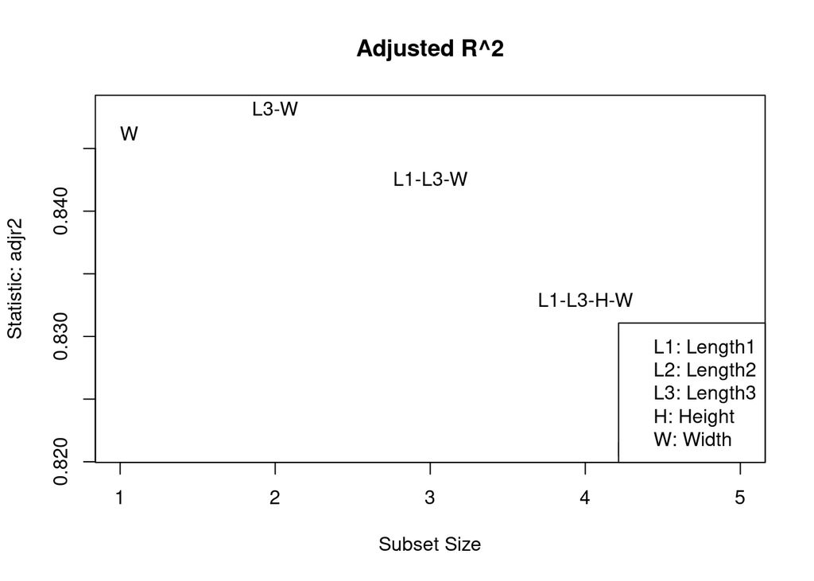

```r
library(car)
subsets(regsubsets.out,statistic="adjr2",legend="bottomright",main="Adjusted R^2")
```

```r
which.max(summary.out$adjr2)
```

```
## [1] 2
```

```r
best.model <- lm(Weight~Length3+Width,data=Roach)
summary(best.model)
```

```
##
## Call:
## lm(formula = Weight ~ Length3 + Width, data = Roach)
##
## Residuals:
##      Min       1Q   Median       3Q      Max
## -111.945   -7.217   -2.824   11.666   61.036
##
## Coefficients:
##             Estimate Std. Error t value Pr(>|t|)
## (Intercept) -319.118     53.768  -5.935 1.63e-05 ***
## Length3        8.278      7.458   1.110    0.282
## Width         72.300     43.551   1.660    0.115
## ---
## Signif. codes:  0 '***' 0.001 '**' 0.01 '*' 0.05 '.' 0.1 ' ' 1
##
## Residual standard error: 34.61 on 17 degrees of freedom
## Multiple R-squared:  0.8641, Adjusted R-squared:  0.8482
## F-statistic: 54.07 on 2 and 17 DF,  p-value: 4.277e-08
```

```r
fullup=lm(Weight~.,data=select(Roach,-Species))
```

Using the two best variables a linear model was used. The best prediction for weight = -319.118 + 8.278 * Length3 + 72.30 * Width Using this model shows all the variables, Roach fish weight can better be predicted when using Length3 and Width of the fish.

## 7.2 Inferential Results

$H_0$ The models show no difference in the prediction of weight Roach fish.

$H_A$ The models help with predicting the weight of Roach fish.

```r
anova(fullup,best.model)
```

```
## Analysis of Variance Table
##
## Model 1: Weight ~ Length1 + Length2 + Length3 + Height + Width
## Model 2: Weight ~ Length3 + Width
##   Res.Df   RSS Df Sum of Sq      F Pr(>F)
## 1     14 19771
## 2     17 20368 -3   -597.11 0.1409 0.9338
```

# 8 Discussion and Conclusion

Using all the variables to come up the best way to predict the weight of Roach fish. It is concluded the Width and Length3 is the best predictor for Roach fish Weight.